# Árboles de Decisión - Laboratorio 4

## Punto 6: Creación de la variable categórica de precio

```r
# Estadísticos descriptivos del precio
summary(listings$price)
```

```
##    Min. 1st Qu.  Median    Mean 3rd Qu.    Max.
##     8.0   120.0   193.0   750.5   326.0 50123.0
```

```r
# Percentiles clave para definir los límites
cuantiles <- quantile(listings$price, probs = c(0.25, 0.33, 0.50, 0.66, 0.75))
print(cuantiles)
```

```
## 25% 33% 50% 66% 75%
## 120 141 193 264 326
```

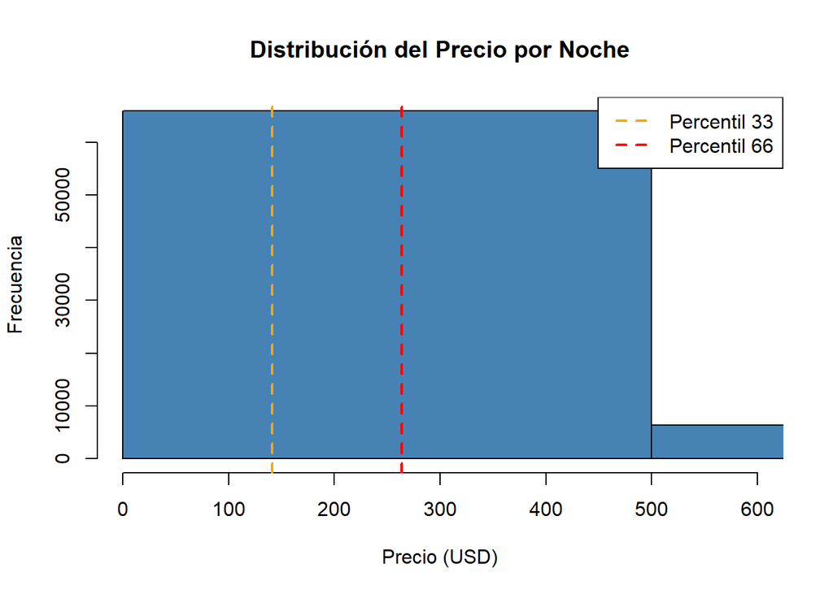

```r
# Histograma de la distribución del precio
hist(listings$price,
     breaks = 150,
     main = "Distribución del Precio por Noche",
     xlab = "Precio (USD)",
     ylab = "Frecuencia",
     col = "steelblue",
     xlim = c(0, 600))
abline(v = quantile(listings$price, 0.33), col = "orange", lwd = 2, lty = 2)
abline(v = quantile(listings$price, 0.66), col = "red", lwd = 2, lty = 2)
legend("topright",
       legend = c("Percentil 33", "Percentil 66"),
       col = c("orange", "red"),
       lty = 2, lwd = 2)
```

```r
# Límites basados en los terciles (percentiles 33 y 66)
p33 <- quantile(listings$price, 0.33)
p66 <- quantile(listings$price, 0.66)

cat("Límite Económica: precio <=", p33, "\n")
```

```
## Límite Económica: precio <= 141
```

```r
cat("Límite Intermedia:", p33, "< precio <=", p66, "\n")
```

```
## Límite Intermedia: 141 < precio <= 264
```

```r
cat("Límite Cara: precio >", p66, "\n")
```

```
## Límite Cara: precio > 264
```

```r
# Crear la variable en el dataset completo
listings$price_category <- cut(
  listings$price,
  breaks = c(-Inf, p33, p66, Inf),
  labels = c("Economica", "Intermedia", "Cara"),
  right = TRUE
)

# Verificar distribución de clases
cat("\nDistribución absoluta:\n")
```

```
##
## Distribución absoluta:
```

```r
print(table(listings$price_category))
```

```
##
##  Economica Intermedia       Cara
##      25185      25164      25897
```

```r
cat("\nDistribución porcentual:\n")
```

```
##
## Distribución porcentual:
```

```r
print(round(prop.table(table(listings$price_category)) * 100, 1))
```

```
##
##  Economica Intermedia       Cara
##         33         33         34
```

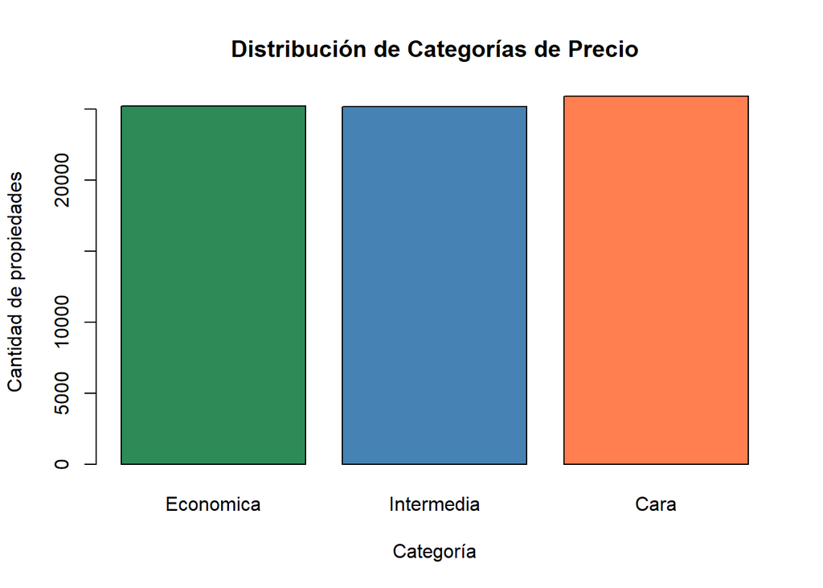

```r
# Gráfico de barras de la distribución de categorías
barplot(table(listings$price_category),
        col = c("seagreen", "steelblue", "coral"),
        main = "Distribución de Categorías de Precio",
        ylab = "Cantidad de propiedades",
        xlab = "Categoría")
```

La variable `price_category` se definió usando los **terciles** de la distribución de precios (percentiles 33 y 66). Este criterio se justifica porque:

- Divide los datos en tres grupos con proporciones aproximadamente iguales (~33% cada uno), evitando clases desbalanceadas que perjudican el entrenamiento de los modelos de clasificación.
- Los límites reflejan la distribución real de los datos y no valores arbitrarios.
- Las propiedades por debajo del percentil 33 se clasifican como **Económicas**, entre el percentil 33 y 66 como **Intermedias**, y por encima del percentil 66 como **Caras**.

```r
# Propagar price_category a train y test usando los índices originales
train$price_category <- listings$price_category[as.numeric(rownames(train))]
test$price_category <- listings$price_category[as.numeric(rownames(test))]

# Verificar ausencia de NAs
cat("NAs en train:", sum(is.na(train$price_category)), "\n")
```

```
## NAs en train: 0
```

```r
cat("NAs en test: ", sum(is.na(test$price_category)), "\n")
```

```
## NAs en test:  0
```

```r
# Verificar distribución en cada conjunto
cat("\nDistribución en Train:\n")
```

```
##
## Distribución en Train:
```

```r
print(round(prop.table(table(train$price_category)) * 100, 1))
```

```
##
##  Economica Intermedia       Cara
##       33.0       32.9       34.1
```

```r
cat("\nDistribución en Test:\n")
```

```
##
## Distribución en Test:
```

```r
print(round(prop.table(table(test$price_category)) * 100, 1))
```

```
##
##  Economica Intermedia       Cara
##       33.1       33.2       33.7
```

## Punto 7: Árbol de Clasificación

Se excluyen `price` y `log_price` del modelo para evitar fuga de información (data leakage), ya que la variable respuesta `price_category` fue generada directamente a partir de `price`.

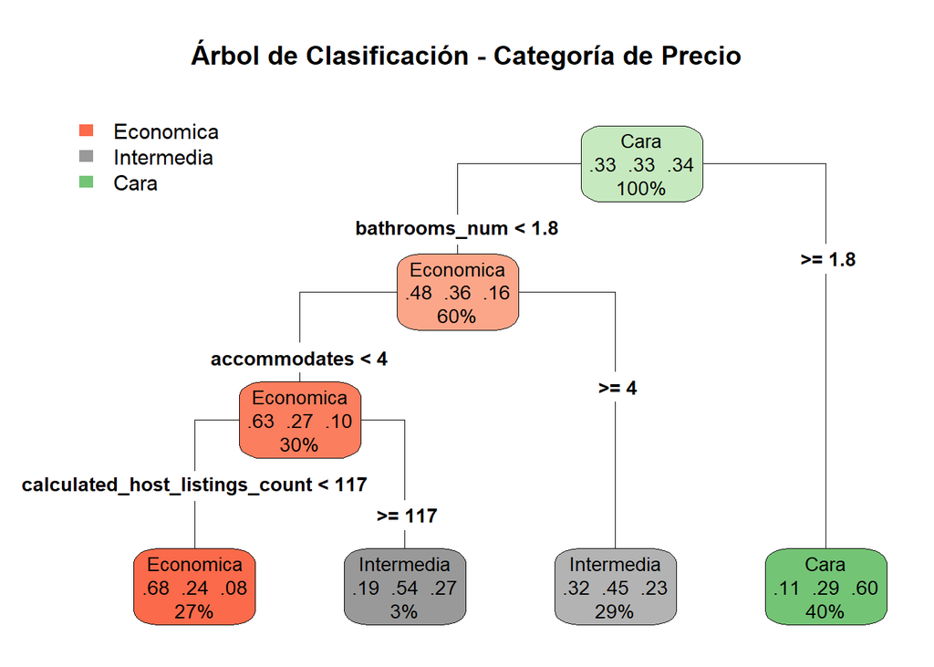

```r
set.seed(123)

arbol_clasificacion <- rpart(
  price_category ~
    accommodates +
    bathrooms_num +
    bedrooms +
    beds +
    host_response_rate +
    host_acceptance_rate +
    calculated_host_listings_count +
    number_of_reviews +
    reviews_per_month +
    review_scores_rating +
    minimum_nights +
    availability_365 +
    room_type +
    host_is_superhost +
    instant_bookable +
    bathroom_type,
  data = train,
  method = "class"
)

# Representación gráfica del árbol
rpart.plot(
  arbol_clasificacion,
  type = 4,
  extra = 104,
  main = "Árbol de Clasificación - Categoría de Precio"
)
```

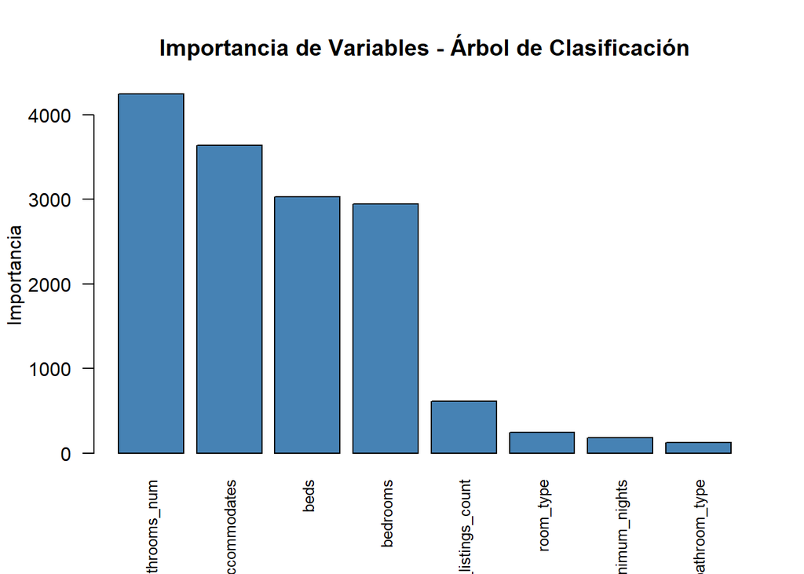

```r
# Importancia de variables según el árbol de clasificación
importancia <- arbol_clasificacion$variable.importance
barplot(
  sort(importancia, decreasing = TRUE),
  las = 2,
  col = "steelblue",
  main = "Importancia de Variables - Árbol de Clasificación",
  ylab = "Importancia",
  cex.names = 0.8
)
```

## Punto 8: Predicción con conjunto de prueba

```r
# Predicción sobre el conjunto de prueba
pred_clasificacion <- predict(arbol_clasificacion, newdata = test, type = "class")

# Matriz de confusión
conf_matrix <- confusionMatrix(pred_clasificacion, test$price_category)
print(conf_matrix)
```

```
## Confusion Matrix and Statistics
##
##             Reference
## Prediction   Economica Intermedia Cara
##   Economica       4276       1568  531
##   Intermedia      2304       3269 1724
##   Cara             989       2749 5464
##
## Overall Statistics
##
##                Accuracy : 0.5687
##                  95% CI : (0.5623, 0.5752)
##     No Information Rate : 0.3375
##     P-Value [Acc > NIR] : < 2.2e-16
##
##                   Kappa : 0.3527
##
##  Mcnemar's Test P-Value : < 2.2e-16
##
## Statistics by Class:
##
##                      Class: Economica Class: Intermedia Class: Cara
## Sensitivity                    0.5649            0.4309      0.7079
## Specificity                    0.8629            0.7365      0.7533
## Pos Pred Value                 0.6707            0.4480      0.5938
## Neg Pred Value                 0.8004            0.7229      0.8351
## Prevalence                     0.3309            0.3316      0.3375
## Detection Rate                 0.1869            0.1429      0.2389
## Detection Prevalence           0.2787            0.3190      0.4023
## Balanced Accuracy              0.7139            0.5837      0.7306
```

## Punto 9: Análisis de la eficiencia con matriz de confusión

```r
# Accuracy general
cat("=== Análisis de la Matriz de Confusión ===\n\n")
```

```
## === Análisis de la Matriz de Confusión ===
```

```r
cat("Accuracy general:", conf_matrix$overall["Accuracy"], "\n")
```

```
## Accuracy general: 0.5687243
```

```r
cat("Kappa:", conf_matrix$overall["Kappa"], "\n\n")
```

```
## Kappa: 0.3526577
```

```r
# Métricas por clase
cat("Métricas por clase:\n")
```

```
## Métricas por clase:
```

```r
print(conf_matrix$byClass[, c("Sensitivity", "Specificity", "Pos Pred Value", "Balanced Accuracy")])
```

```
##                   Sensitivity Specificity Pos Pred Value Balanced Accuracy
## Class: Economica    0.5649359   0.8628553      0.6707451         0.7138956
## Class: Intermedia   0.4309254   0.7365254      0.4479923         0.5837254
## Class: Cara         0.7078637   0.7533487      0.5937840         0.7306062
```

```r
# Tabla de confusión detallada para análisis de errores
cat("\nTabla de confusión (filas = predicción, columnas = real):\n")
```

```
##
## Tabla de confusión (filas = predicción, columnas = real):
```

```r
tabla_conf <- conf_matrix$table
print(tabla_conf)
```

```
##             Reference
## Prediction   Economica Intermedia Cara
##   Economica       4276       1568  531
##   Intermedia      2304       3269 1724
##   Cara             989       2749 5464
```

```r
# Calcular errores por clase
cat("\n=== Análisis de errores por categoría ===\n")
```

```
##
## === Análisis de errores por categoría ===
```

```r
for (clase in levels(test$price_category)) {
  total_real <- sum(tabla_conf[, clase])
  correctos <- tabla_conf[clase, clase]
  incorrectos <- total_real - correctos
  tasa_error <- incorrectos / total_real
  cat(paste0("\n", clase, ":\n"))
  cat("  Total real:", total_real, "\n")
  cat("  Clasificados correctamente:", correctos, "\n")
  cat("  Clasificados incorrectamente:", incorrectos, "\n")
  cat("  Tasa de error:", round(tasa_error * 100, 2), "%\n")
}
```

```
##
## Economica:
##   Total real: 7569
##   Clasificados correctamente: 4276
##   Clasificados incorrectamente: 3293
##   Tasa de error: 43.51 %
##
## Intermedia:
##   Total real: 7586
##   Clasificados correctamente: 3269
##   Clasificados incorrectamente: 4317
##   Tasa de error: 56.91 %
##
## Cara:
##   Total real: 7719
##   Clasificados correctamente: 5464
##   Clasificados incorrectamente: 2255
##   Tasa de error: 29.21 %
```

```r
# Donde se equivocó más y menos
sensitivities <- conf_matrix$byClass[, "Sensitivity"]
cat("\n\nClase donde el modelo se equivocó MENOS (mayor Sensitivity):",
    names(which.max(sensitivities)),
    "con Sensitivity:", max(sensitivities), "\n")
```

```
##
##
## Clase donde el modelo se equivocó MENOS (mayor Sensitivity): Class: Cara con Sensitivity: 0.7078637
```

```r
cat("Clase donde el modelo se equivocó MÁS (menor Sensitivity):",
    names(which.min(sensitivities)),
    "con Sensitivity:", min(sensitivities), "\n")
```

```
## Clase donde el modelo se equivocó MÁS (menor Sensitivity): Class: Intermedia con Sensitivity: 0.4309254
```

```r
cat("\n=== Importancia de los errores ===\n\n")
```

```
##
## === Importancia de los errores ===
```

```r
cat("Los errores entre categorías adyacentes (Económica-Intermedia o Intermedia-Cara)\n")
```

```
## Los errores entre categorías adyacentes (Económica-Intermedia o Intermedia-Cara)
```

```r
cat("son menos graves que los errores entre categorías extremas (Económica-Cara),\n")
```

```
## son menos graves que los errores entre categorías extremas (Económica-Cara),
```

```r
cat("ya que confundir una propiedad económica con una cara tendría un impacto\n")
```

```
## ya que confundir una propiedad económica con una cara tendría un impacto
```

```r
cat("significativo en la estrategia de precios de SmartStay Advisors.\n\n")
```

```
## significativo en la estrategia de precios de SmartStay Advisors.
```

```r
# Errores graves: confundir Económica con Cara o viceversa
errores_graves <- tabla_conf["Economica", "Cara"] + tabla_conf["Cara", "Economica"]
errores_totales <- sum(tabla_conf) - sum(diag(tabla_conf))
cat("Errores graves (Económica<->Cara):", errores_graves, "\n")
```

```
## Errores graves (Económica<->Cara): 1520
```

```r
cat("Errores totales:", errores_totales, "\n")
```

```
## Errores totales: 9865
```

```r
cat("Proporción de errores graves:", round(errores_graves / errores_totales * 100, 2), "%\n")
```

```
## Proporción de errores graves: 15.41 %
```

El análisis de la matriz de confusión revela en qué categorías el modelo acierta más y en cuáles se confunde. Los errores entre categorías adyacentes son más frecuentes pero menos problemáticos que las confusiones entre Económica y Cara. Para SmartStay Advisors, confundir una propiedad cara con una económica podría significar recomendar propiedades sobrevaloradas a clientes con presupuesto limitado, mientras que el error inverso implicaría perder oportunidades de negocio en propiedades premium.

## Punto 10: Modelo con Validación Cruzada

```r
# Configurar la validación cruzada (10-fold CV)
train_control <- trainControl(method = "cv", number = 10)

# Entrenar el modelo de clasificación con Validación Cruzada
set.seed(123)
modelo_cv <- train(
  price_category ~
    accommodates + bathrooms_num + bedrooms + beds +
    host_response_rate + host_acceptance_rate +
    calculated_host_listings_count + number_of_reviews +
    reviews_per_month + review_scores_rating +
    minimum_nights + availability_365 +
    room_type + host_is_superhost +
    instant_bookable + bathroom_type,
  data = train,
  method = "rpart",
  trControl = train_control,
  tuneLength = 10
)

# Ver el mejor modelo encontrado
print(modelo_cv)
```

```
## CART
##
## 53372 samples
##    16 predictor
##     3 classes: 'Economica', 'Intermedia', 'Cara'
##
## No pre-processing
## Resampling: Cross-Validated (10 fold)
## Summary of sample sizes: 48035, 48034, 48035, 48034, 48035, 48035, ...
## Resampling results across tuning parameters:
##
##   cp           Accuracy   Kappa
##   0.002315736  0.6205122  0.4306298
##   0.003002406  0.6159031  0.4238681
##   0.003608570  0.6073779  0.4107531
##   0.004397056  0.5983279  0.3974208
##   0.004460988  0.5956675  0.3934988
##   0.005753822  0.5876674  0.3812535
##   0.007472865  0.5793299  0.3683703
##   0.015627664  0.5718731  0.3571357
##   0.056771041  0.5434316  0.3142561
##   0.283542649  0.4321367  0.1422729
##
## Accuracy was used to select the optimal model using the largest value.
## The final value used for the model was cp = 0.002315736.
```

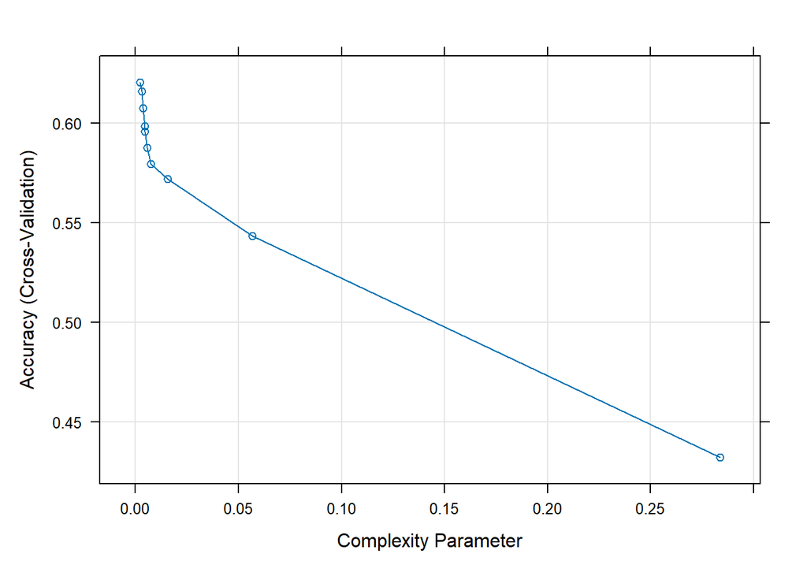

```r
plot(modelo_cv)
```

```r
# Predecir con el nuevo modelo en el conjunto de prueba
pred_cv <- predict(modelo_cv, newdata = test)

# Generar la matriz de confusión para comparar
conf_matrix_cv <- confusionMatrix(pred_cv, test$price_category)
print(conf_matrix_cv)
```

```
## Confusion Matrix and Statistics
##
##             Reference
## Prediction   Economica Intermedia Cara
##   Economica       5307       2084  654
##   Intermedia      1749       3595 1997
##   Cara             513       1907 5068
##
## Overall Statistics
##
##                Accuracy : 0.6107
##                  95% CI : (0.6044, 0.6171)
##     No Information Rate : 0.3375
##     P-Value [Acc > NIR] : < 2.2e-16
##
##                   Kappa : 0.4161
##
##  Mcnemar's Test P-Value : 1.76e-10
##
## Statistics by Class:
##
##                      Class: Economica Class: Intermedia Class: Cara
## Sensitivity                    0.7011            0.4739      0.6566
## Specificity                    0.8211            0.7550      0.8403
## Pos Pred Value                 0.6597            0.4897      0.6768
## Neg Pred Value                 0.8475            0.7431      0.8277
## Prevalence                     0.3309            0.3316      0.3375
## Detection Rate                 0.2320            0.1572      0.2216
## Detection Prevalence           0.3517            0.3209      0.3274
## Balanced Accuracy              0.7611            0.6144      0.7484
```

```r
cat("=== Comparación: Árbol base vs Validación Cruzada ===\n")
```

```
## === Comparación: Árbol base vs Validación Cruzada ===
```

```r
cat("Accuracy Árbol base:       ", conf_matrix$overall["Accuracy"], "\n")
```

```
## Accuracy Árbol base:        0.5687243
```

```r
cat("Accuracy Validación Cruzada:", conf_matrix_cv$overall["Accuracy"], "\n")
```

```
## Accuracy Validación Cruzada: 0.6107371
```

```r
cat("Kappa Árbol base:          ", conf_matrix$overall["Kappa"], "\n")
```

```
## Kappa Árbol base:           0.3526577
```

```r
cat("Kappa Validación Cruzada:  ", conf_matrix_cv$overall["Kappa"], "\n")
```

```
## Kappa Validación Cruzada:   0.416148
```

```r
if (conf_matrix_cv$overall["Accuracy"] > conf_matrix$overall["Accuracy"]) {
  cat("\nEl modelo con validación cruzada obtuvo mejor accuracy.\n")
} else {
  cat("\nEl modelo base obtuvo igual o mejor accuracy que el modelo con validación cruzada.\n")
}
```

```
##
## El modelo con validación cruzada obtuvo mejor accuracy.
```

La validación cruzada con 10 folds permite encontrar el parámetro de complejidad (cp) óptimo, evaluando múltiples configuraciones del árbol sobre distintas particiones del conjunto de entrenamiento. Esto reduce el riesgo de sobreajuste respecto al modelo entrenado sin CV.

## Punto 11: Modelos de clasificación con diferentes profundidades

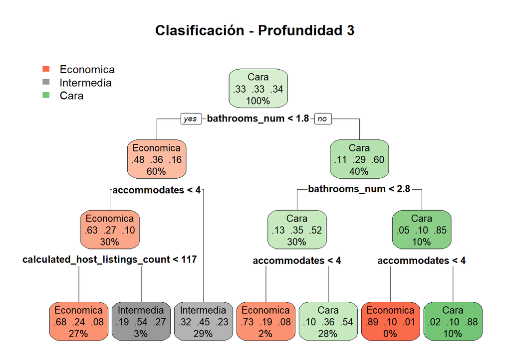

```r
# NOTA: Se usa cp=0.001 para que rpart no pode el árbol antes de alcanzar
# la profundidad deseada. Sin esto, rpart aplica cp=0.01 por defecto
# y todos los árboles terminan iguales.
set.seed(123)
modelo_clas_prof3 <- rpart(
  price_category ~
    accommodates + bathrooms_num + bedrooms + beds +
    host_response_rate + host_acceptance_rate +
    calculated_host_listings_count + number_of_reviews +
    reviews_per_month + review_scores_rating +
    minimum_nights + availability_365 +
    room_type + host_is_superhost +
    instant_bookable + bathroom_type,
  data = train,
  method = "class",
  control = rpart.control(maxdepth = 3, cp = 0.001)
)
rpart.plot(modelo_clas_prof3, main = "Clasificación - Profundidad 3")
```

```r
pred_prof3 <- predict(modelo_clas_prof3, newdata = test, type = "class")
conf_matrix_prof3 <- confusionMatrix(pred_prof3, test$price_category)
cat("=== Profundidad 3 ===\n")
```

```
## === Profundidad 3 ===
```

```r
print(conf_matrix_prof3$overall[c("Accuracy", "Kappa")])
```

```
##  Accuracy     Kappa
## 0.5799598 0.3696330
```

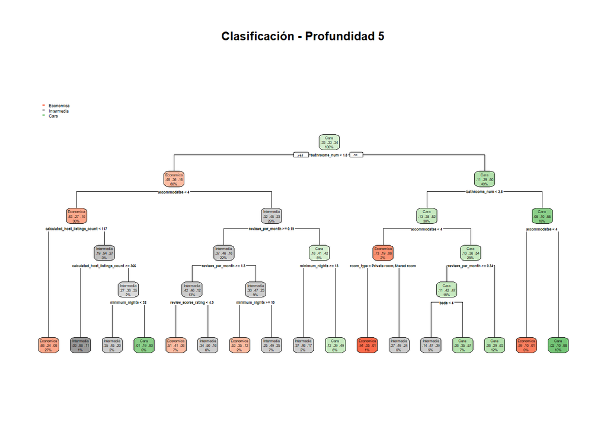

```r
set.seed(123)
modelo_clas_prof5 <- rpart(
  price_category ~
    accommodates + bathrooms_num + bedrooms + beds +
    host_response_rate + host_acceptance_rate +
    calculated_host_listings_count + number_of_reviews +
    reviews_per_month + review_scores_rating +
    minimum_nights + availability_365 +
    room_type + host_is_superhost +
    instant_bookable + bathroom_type,
  data = train,
  method = "class",
  control = rpart.control(maxdepth = 5, cp = 0.001)
)
rpart.plot(modelo_clas_prof5, main = "Clasificación - Profundidad 5")
```

```r
pred_prof5 <- predict(modelo_clas_prof5, newdata = test, type = "class")
conf_matrix_prof5 <- confusionMatrix(pred_prof5, test$price_category)
cat("=== Profundidad 5 ===\n")
```

```
## === Profundidad 5 ===
```

```r
print(conf_matrix_prof5$overall[c("Accuracy", "Kappa")])
```

```
##  Accuracy     Kappa
## 0.6059718 0.4088482
```

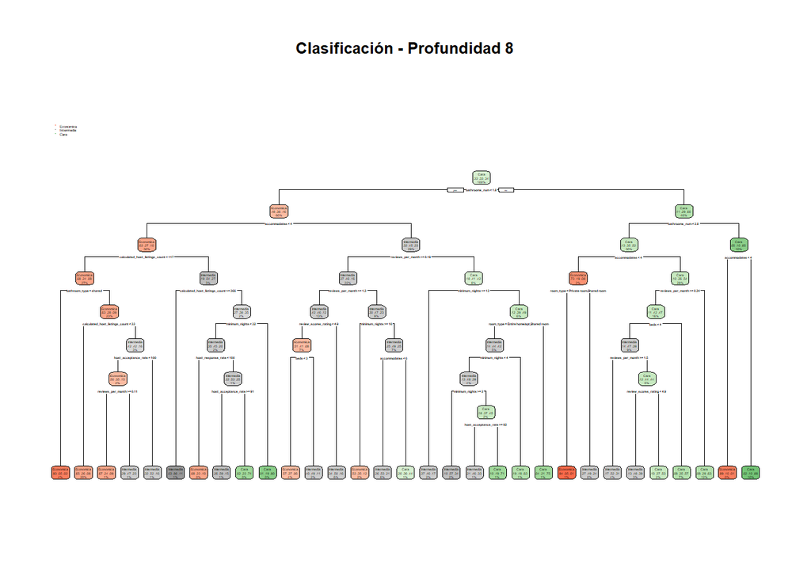

```r
set.seed(123)
modelo_clas_prof8 <- rpart(
  price_category ~
    accommodates + bathrooms_num + bedrooms + beds +
    host_response_rate + host_acceptance_rate +
    calculated_host_listings_count + number_of_reviews +
    reviews_per_month + review_scores_rating +
    minimum_nights + availability_365 +
    room_type + host_is_superhost +
    instant_bookable + bathroom_type,
  data = train,
  method = "class",
  control = rpart.control(maxdepth = 8, cp = 0.001)
)
rpart.plot(modelo_clas_prof8, main = "Clasificación - Profundidad 8")
```

```r
pred_prof8 <- predict(modelo_clas_prof8, newdata = test, type = "class")
conf_matrix_prof8 <- confusionMatrix(pred_prof8, test$price_category)
cat("=== Profundidad 8 ===\n")
```

```
## === Profundidad 8 ===
```

```r
print(conf_matrix_prof8$overall[c("Accuracy", "Kappa")])
```

```
##  Accuracy     Kappa
## 0.6285739 0.4427441
```

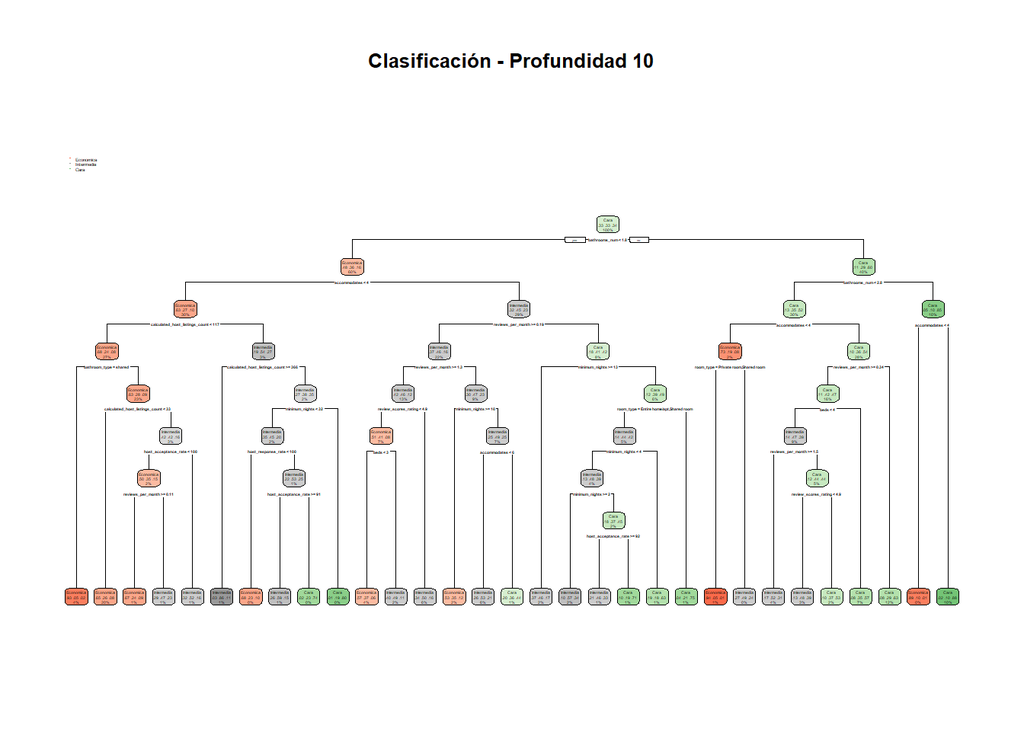

```r
set.seed(123)
modelo_clas_prof10 <- rpart(
  price_category ~
    accommodates + bathrooms_num + bedrooms + beds +
    host_response_rate + host_acceptance_rate +
    calculated_host_listings_count + number_of_reviews +
    reviews_per_month + review_scores_rating +
    minimum_nights + availability_365 +
    room_type + host_is_superhost +
    instant_bookable + bathroom_type,
  data = train,
  method = "class",
  control = rpart.control(maxdepth = 10, cp = 0.001)
)
rpart.plot(modelo_clas_prof10, main = "Clasificación - Profundidad 10")
```

```r
pred_prof10 <- predict(modelo_clas_prof10, newdata = test, type = "class")
conf_matrix_prof10 <- confusionMatrix(pred_prof10, test$price_category)
cat("=== Profundidad 10 ===\n")
```

```
## === Profundidad 10 ===
```

```r
print(conf_matrix_prof10$overall[c("Accuracy", "Kappa")])
```

```
##  Accuracy     Kappa
## 0.6285739 0.4427441
```

### Resumen comparativo de árboles de clasificación

```r
resumen_clasificacion <- data.frame(
  Modelo = c("Árbol base (default)", "Profundidad 3", "Profundidad 5",
             "Profundidad 8", "Profundidad 10", "Validación Cruzada"),
  Accuracy = c(
    conf_matrix$overall["Accuracy"],
    conf_matrix_prof3$overall["Accuracy"],
    conf_matrix_prof5$overall["Accuracy"],
    conf_matrix_prof8$overall["Accuracy"],
    conf_matrix_prof10$overall["Accuracy"],
    conf_matrix_cv$overall["Accuracy"]
  ),
  Kappa = c(
    conf_matrix$overall["Kappa"],
    conf_matrix_prof3$overall["Kappa"],
    conf_matrix_prof5$overall["Kappa"],
    conf_matrix_prof8$overall["Kappa"],
    conf_matrix_prof10$overall["Kappa"],
    conf_matrix_cv$overall["Kappa"]
  )
)

print(resumen_clasificacion)
```

```
##                 Modelo  Accuracy     Kappa
## 1 Árbol base (default) 0.5687243 0.3526577
## 2        Profundidad 3 0.5799598 0.3696330
## 3        Profundidad 5 0.6059718 0.4088482
## 4        Profundidad 8 0.6285739 0.4427441
## 5       Profundidad 10 0.6285739 0.4427441
## 6   Validación Cruzada 0.6107371 0.4161480
```

```r
mejor_clas_idx <- which.max(resumen_clasificacion$Accuracy)
cat("\nMejor modelo de clasificación:", resumen_clasificacion$Modelo[mejor_clas_idx], "\n")
```

```
##
## Mejor modelo de clasificación: Profundidad 8
```

```r
cat("Con Accuracy:", resumen_clasificacion$Accuracy[mejor_clas_idx], "\n")
```

```
## Con Accuracy: 0.6285739
```

```r
cat("Con Kappa:", resumen_clasificacion$Kappa[mejor_clas_idx], "\n")
```

```
## Con Kappa: 0.4427441
```

Se evaluaron árboles de clasificación con profundidades de 3, 5, 8 y 10 además del modelo base y el modelo con validación cruzada. Un árbol poco profundo (3) es muy simple y puede subajustar, mientras que uno muy profundo (10) captura más reglas pero puede sobreajustarse. El modelo con el mayor accuracy en el conjunto de prueba es el que mejor generaliza.

## Punto 12: Random Forest

### 12a. Random Forest para Regresión (predicción del precio)

```r
set.seed(123)

# Seleccionar solo las columnas necesarias para evitar problemas con factores de muchos niveles
vars_modelo <- c("price", "accommodates", "bathrooms_num", "bedrooms", "beds",
                 "host_response_rate", "host_acceptance_rate",
                 "calculated_host_listings_count", "number_of_reviews",
                 "reviews_per_month", "review_scores_rating",
                 "minimum_nights", "availability_365",
                 "room_type", "host_is_superhost", "instant_bookable", "bathroom_type")

train_rf <- train[, vars_modelo]
test_rf <- test[, vars_modelo]

# Eliminar filas con NA en train y test para Random Forest
train_rf <- na.omit(train_rf)
test_rf <- na.omit(test_rf)

# Usar una muestra del train para que RF no tarde demasiado con datasets grandes
if (nrow(train_rf) > 10000) {
  set.seed(123)
  sample_rf <- sample(1:nrow(train_rf), 10000)
  train_rf_sample <- train_rf[sample_rf, ]
  cat("Se usó una muestra de 10,000 observaciones para Random Forest (de", nrow(train_rf), "totales)\n")
} else {
  train_rf_sample <- train_rf
}
```

```
## Se usó una muestra de 10,000 observaciones para Random Forest (de 53372 totales)
```

```r
rf_regresion <- randomForest(
  price ~ .,
  data = train_rf_sample,
  ntree = 100,
  na.action = na.omit
)

print(rf_regresion)
```

```
##
## Call:
##  randomForest(formula = price ~ ., data = train_rf_sample, ntree = 100,      na.action = na.omit)
##                Type of random forest: regression
##                      Number of trees: 100
## No. of variables tried at each split: 5
##
##           Mean of squared residuals: 5624343
##                     % Var explained: 65.03
```

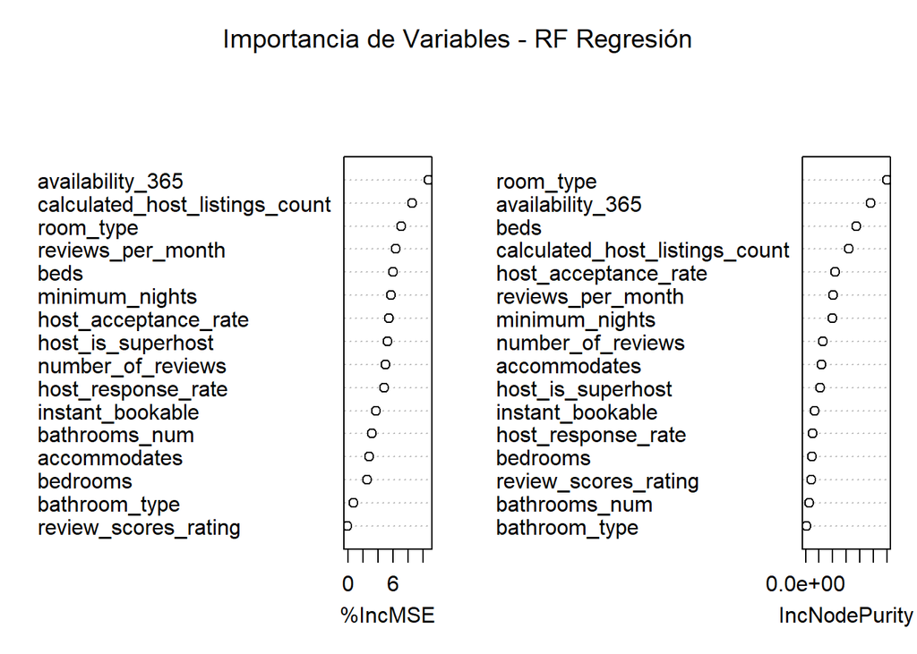

```r
# Importancia de variables (se entrena un modelo pequeño aparte para calcularla)
rf_imp <- randomForest(price ~ ., data = train_rf_sample, ntree = 30, importance = TRUE)
varImpPlot(rf_imp, main = "Importancia de Variables - RF Regresión")
```

```r
# Predicción en test
pred_rf_reg <- predict(rf_regresion, newdata = test_rf)

# Métricas
rmse_rf_test <- RMSE(pred_rf_reg, test_rf$price)
mse_rf_test <- mean((pred_rf_reg - test_rf$price)^2)
r2_rf_test <- cor(pred_rf_reg, test_rf$price)^2

# Predicción en train
pred_rf_train <- predict(rf_regresion, newdata = train_rf)
rmse_rf_train <- RMSE(pred_rf_train, train_rf$price)

cat("=== Random Forest - Regresión ===\n")
```

```
## === Random Forest - Regresión ===
```

```r
cat("RMSE Test: ", rmse_rf_test, "\n")
```

```
## RMSE Test:  2410.265
```

```r
cat("MSE Test:  ", mse_rf_test, "\n")
```

```
## MSE Test:   5809379
```

```r
cat("R² Test:   ", r2_rf_test, "\n")
```

```
## R² Test:    0.6907288
```

```r
cat("RMSE Train:", rmse_rf_train, "\n")
```

```
## RMSE Train: 2185.977
```

```r
cat("Diferencia relativa RMSE (%):",
    abs(rmse_rf_test - rmse_rf_train) / rmse_rf_train * 100, "\n")
```

```
## Diferencia relativa RMSE (%): 10.26031
```

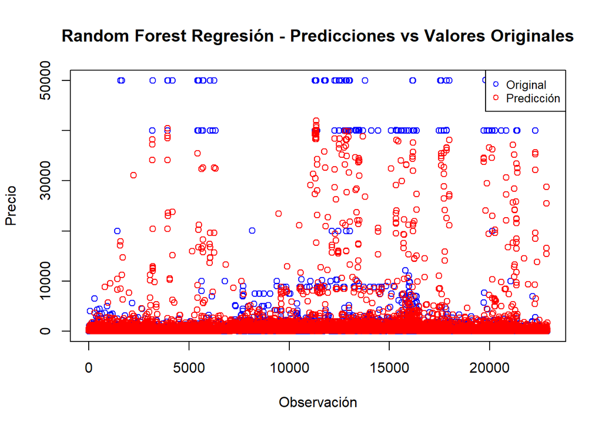

```r
plot(test_rf$price, col = "blue",
     main = "Random Forest Regresión - Predicciones vs Valores Originales",
     ylab = "Precio", xlab = "Observación")
points(pred_rf_reg, col = "red")
legend("topright",
       legend = c("Original", "Predicción"),
       col = c("blue", "red"),
       pch = 1, cex = 0.8)
```

### 12b. Random Forest para Clasificación

```r
set.seed(123)

vars_clas <- c("price_category", "accommodates", "bathrooms_num", "bedrooms", "beds",
               "host_response_rate", "host_acceptance_rate",
               "calculated_host_listings_count", "number_of_reviews",
               "reviews_per_month", "review_scores_rating",
               "minimum_nights", "availability_365",
               "room_type", "host_is_superhost", "instant_bookable", "bathroom_type")

train_rf_clas <- train[, vars_clas]
test_rf_clas <- test[, vars_clas]

# Eliminar filas con NA
train_rf_clas <- na.omit(train_rf_clas)
test_rf_clas <- na.omit(test_rf_clas)

# Usar muestra si el dataset es muy grande
if (nrow(train_rf_clas) > 10000) {
  set.seed(123)
  sample_rf_clas <- sample(1:nrow(train_rf_clas), 10000)
  train_rf_clas_sample <- train_rf_clas[sample_rf_clas, ]
  cat("Se usó una muestra de 10,000 observaciones para RF Clasificación\n")
} else {
  train_rf_clas_sample <- train_rf_clas
}
```

```
## Se usó una muestra de 10,000 observaciones para RF Clasificación
```

```r
rf_clasificacion <- randomForest(
  price_category ~ .,
  data = train_rf_clas_sample,
  ntree = 100,
  na.action = na.omit
)

print(rf_clasificacion)
```

```
##
## Call:
##  randomForest(formula = price_category ~ ., data = train_rf_clas_sample,      ntree = 100, na.action = na.omit)
##                Type of random forest: classification
##                      Number of trees: 100
## No. of variables tried at each split: 4
##
##         OOB estimate of  error rate: 33.24%
## Confusion matrix:
##            Economica Intermedia Cara class.error
## Economica       2424        688  170   0.2614260
## Intermedia       844       1756  731   0.4728310
## Cara             230        661 2496   0.2630647
```

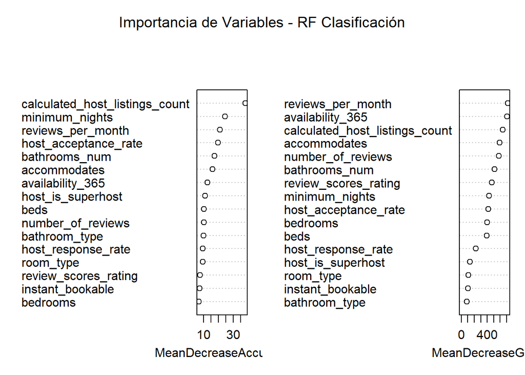

```r
# Importancia de variables (modelo pequeño aparte)
rf_imp_clas <- randomForest(price_category ~ ., data = train_rf_clas_sample, ntree = 30, importance = TRUE)
varImpPlot(rf_imp_clas, main = "Importancia de Variables - RF Clasificación")
```

```r
# Predicción en test
pred_rf_clas <- predict(rf_clasificacion, newdata = test_rf_clas)

# Matriz de confusión
conf_matrix_rf <- confusionMatrix(pred_rf_clas, test_rf_clas$price_category)
print(conf_matrix_rf)
```

```
## Confusion Matrix and Statistics
##
##             Reference
## Prediction   Economica Intermedia Cara
##   Economica       5540       1826  457
##   Intermedia      1640       4118 1610
##   Cara             389       1642 5652
##
## Overall Statistics
##
##                Accuracy : 0.6693
##                  95% CI : (0.6632, 0.6754)
##     No Information Rate : 0.3375
##     P-Value [Acc > NIR] : < 2.2e-16
##
##                   Kappa : 0.504
##
##  Mcnemar's Test P-Value : 0.001269
##
## Statistics by Class:
##
##                      Class: Economica Class: Intermedia Class: Cara
## Sensitivity                    0.7319            0.5428      0.7322
## Specificity                    0.8508            0.7874      0.8660
## Pos Pred Value                 0.7082            0.5589      0.7357
## Neg Pred Value                 0.8652            0.7763      0.8639
## Prevalence                     0.3309            0.3316      0.3375
## Detection Rate                 0.2422            0.1800      0.2471
## Detection Prevalence           0.3420            0.3221      0.3359
## Balanced Accuracy              0.7914            0.6651      0.7991
```

```r
cat("=== Análisis de la Matriz de Confusión - Random Forest ===\n\n")
```

```
## === Análisis de la Matriz de Confusión - Random Forest ===
```

```r
cat("Accuracy:", conf_matrix_rf$overall["Accuracy"], "\n")
```

```
## Accuracy: 0.6693189
```

```r
cat("Kappa:", conf_matrix_rf$overall["Kappa"], "\n\n")
```

```
## Kappa: 0.5039721
```

```r
cat("Métricas por clase:\n")
```

```
## Métricas por clase:
```

```r
print(conf_matrix_rf$byClass[, c("Sensitivity", "Specificity", "Pos Pred Value", "Balanced Accuracy")])
```

```
##                   Sensitivity Specificity Pos Pred Value Balanced Accuracy
## Class: Economica    0.7319329   0.8508331      0.7081682         0.7913830
## Class: Intermedia   0.5428421   0.7874150      0.5589034         0.6651285
## Class: Cara         0.7322192   0.8659848      0.7356501         0.7991020
```

```r
# Análisis de errores graves
tabla_rf <- conf_matrix_rf$table
errores_graves_rf <- tabla_rf["Economica", "Cara"] + tabla_rf["Cara", "Economica"]
errores_totales_rf <- sum(tabla_rf) - sum(diag(tabla_rf))
cat("\nErrores graves (Económica<->Cara):", errores_graves_rf, "\n")
```

```
##
## Errores graves (Económica<->Cara): 846
```

```r
cat("Errores totales:", errores_totales_rf, "\n")
```

```
## Errores totales: 7564
```

```r
cat("Proporción de errores graves:", round(errores_graves_rf / errores_totales_rf * 100, 2), "%\n")
```

```
## Proporción de errores graves: 11.18 %
```

### 12c. Random Forest con diferentes números de árboles

```r
set.seed(123)

ntrees <- c(25, 50, 100, 150, 200)
resultados_rf <- data.frame(
  ntree = integer(),
  Accuracy = numeric(),
  Kappa = numeric(),
  RMSE_reg = numeric()
)

for (nt in ntrees) {
  cat("Entrenando RF con ntree =", nt, "...\n")

  # Clasificación (usando la muestra)
  rf_temp_clas <- randomForest(price_category ~ ., data = train_rf_clas_sample, ntree = nt, na.action = na.omit)
  pred_temp_clas <- predict(rf_temp_clas, newdata = test_rf_clas)
  cm_temp <- confusionMatrix(pred_temp_clas, test_rf_clas$price_category)

  # Regresión (usando la muestra)
  rf_temp_reg <- randomForest(price ~ ., data = train_rf_sample, ntree = nt, na.action = na.omit)
  pred_temp_reg <- predict(rf_temp_reg, newdata = test_rf)
  rmse_temp <- RMSE(pred_temp_reg, test_rf$price)

  resultados_rf <- rbind(resultados_rf, data.frame(
    ntree = nt,
    Accuracy = cm_temp$overall["Accuracy"],
    Kappa = cm_temp$overall["Kappa"],
    RMSE_reg = rmse_temp
  ))
}
```

```
## Entrenando RF con ntree = 25 ...
## Entrenando RF con ntree = 50 ...
## Entrenando RF con ntree = 100 ...
## Entrenando RF con ntree = 150 ...
## Entrenando RF con ntree = 200 ...
```

```r
print(resultados_rf)
```

```
##           ntree  Accuracy     Kappa RMSE_reg
## Accuracy     25 0.6551543 0.4827272 2455.805
## Accuracy1    50 0.6610999 0.4916572 2397.716
## Accuracy2   100 0.6697123 0.5045572 2415.613
## Accuracy3   150 0.6692752 0.5039094 2369.695
## Accuracy4   200 0.6704118 0.5056051 2378.853
```

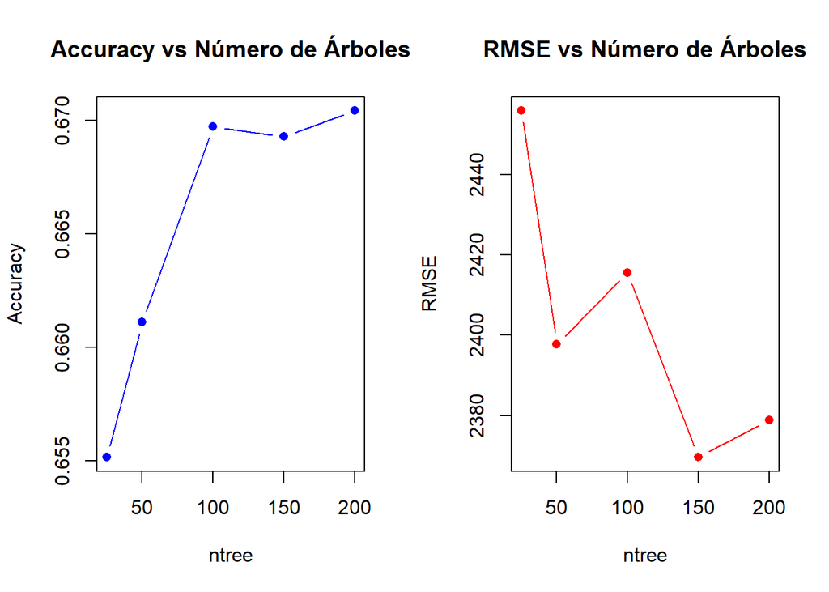

```r
# Gráficos de convergencia
par(mfrow = c(1, 2))
plot(resultados_rf$ntree, resultados_rf$Accuracy, type = "b", col = "blue",
     main = "Accuracy vs Número de Árboles", xlab = "ntree", ylab = "Accuracy", pch = 16)
plot(resultados_rf$ntree, resultados_rf$RMSE_reg, type = "b", col = "red",
     main = "RMSE vs Número de Árboles", xlab = "ntree", ylab = "RMSE", pch = 16)
```

```r
par(mfrow = c(1, 1))
```

Random Forest agrega múltiples árboles de decisión entrenados con submuestras aleatorias de los datos y subconjuntos de variables, lo que reduce la varianza y el sobreajuste. En general, a medida que aumenta el número de árboles, el rendimiento se estabiliza. Se observa que después de cierto punto, agregar más árboles no mejora significativamente ni el accuracy ni el RMSE.